# Wie erstelle ich ein R-package

Eine simple Einführung

## Einführung

Ein **R-Package** ist eine strukturierte Sammlung von Funktionen, Datensätzen und Dokumentation, die gemeinsam eine bestimmte Funktionalität bereitstellen.  
Fast alles, was man in R nutzt (z. B. `ggplot2`, `dplyr`, `stringr`, `tidyverse`), ist ein Package.

R-Packages dienen dazu, wiederverwendbaren Code in einer klar definierten Struktur zu organisieren, zu dokumentieren und weiterzugeben. Dies ist besonders nützlich, wenn man Funktionen mehrfach nutzt, Projekte gemeinsam bearbeitet oder eigene Tools für andere entwickeln möchte.

### CRAN

CRAN steht für **Comprehensive R Archive Network** und ist das zentrale Verzeichnis und Distributionsnetzwerk für R-Pakete. Man kann es sich vorstellen wie den „App Store“ oder „Play Store“ für R-Pakete. CRAN hostet offizielle, geprüfte R-Packages (z. B. ggplot2, dplyr, tidyr, etc.).

#### Wofür braucht man CRAN?

Mit dem Code `install.packages("ggplot2")` lädt R das Paket `ggplot2` automatisch von CRAN herunter, kompiliert es (wenn nötig) und installiert es lokal.

#### Wie funktioniert CRAN?

CRAN ist kein einzelner Server, sondern ein Netzwerk aus Spiegelservern (Mirrors) auf der ganzen Welt. Wenn du ein Paket installierst, wählt R automatisch den geografisch nächstgelegenen Mirror, um schnell herunterzuladen.

#### Vor- und Nachteile von CRAN

| **Vorteile** | **Nachteile** |
| --- | --- |
| Hohe Sichtbarkeit und einfache Installation über `install.packages()` | Strenge Einreichungs- und Prüfungsrichtlinien |
| Automatische Updates und zuverlässige Verfügbarkeit | Langer und teils komplexer Veröffentlichungsprozess |
| Qualitätssicherung durch umfangreiche Tests auf verschiedenen Systemen | Wenig Flexibilität für schnelle Änderungen oder experimentelle Versionen |

#### Alternativen zu CRAN

- *GitHub* (schnelle und flexible Veröffentlichung von Paketen)
- *GitLab* (ähnlich wie GitHub, aber für interne Projekte oder Firmen-Repos)
- *tar.gz* (Ein komprimiertes Archiv, das viele Dateien, wie beispielsweise ein R-Package mit Unterordnern, enthält und weniger Speicher benötigt; Paket kann lokal kompiliert und als Datei geteilt werden)

## Erstellung eines R-Packages

Im Folgenden findest du eine Schritt-für-Schritt-Anleitung, wie du in **RStudio** ein eigenes Package erstellst – als *tar.gz* oder für die Veröffentlichung auf *GitHub*.

```r
# ==============================
# Minimal Base-R Package Script
# ==============================


# --- 0. Install Packages ---
pacman::p_load("roxygen2", "remotes")


# --- 1. Define paths and create R folder ---
pkg_name <- "PackageName"
pkg_path <- file.path("Package/Ablage/Pfad", pkg_name)          # <-- replace with your package folder path
output_path <- file.path("Package/Output/tar.gz/Pfad")          # <-- replace with desired output folder
dir.create(pkg_path, showWarnings = FALSE, recursive = TRUE)
dir.create(output_path, showWarnings = FALSE, recursive = TRUE)
r_path <- file.path(pkg_path, "R")
dir.create(r_path, showWarnings = FALSE, recursive = TRUE)


# --- 2. Create DESCRIPTION ---
desc <- sprintf("
Package: %s
Type: Package
Title: Minimal Base-R Example Package
Version: 0.1.0
Author: Max Mustermann
Maintainer: Max Mustermann <max@example.com>
Description: Minimal package example using only base R.
License: MIT
Encoding: UTF-8
LazyData: true
", pkg_name)
writeLines(desc, con = file.path(pkg_path, "DESCRIPTION")) # write DESCRIPTION


# --- 3. Add package content ---
package_content <- "
#' violet4
#'
#' violet colours palette with four colors.
#'
#' @format A vector of color hex codes.
#' @export
violet4 <- rev(c('#2E1235', '#662673', '#B375AB', '#E7CEE2'))

#' yellow4
#'
#' yellow colours palette with four colors.
#'
#' @format A vector of color hex codes.
#' @export
yellow4 <- rev(c('#45381D', '#7F5F1A', '#CD9C00', '#FFDA80'))

#' stacked_bar
#'
#' Create a stacked bar plot using ggplot2.
#'
#' @param data Data frame containing the variables to plot
#' @param x_axis Column name for x-axis values
#' @param y_axis Column name for y-axis values
#' @param title Plot title
#' @param legend_title Legend title
#' @param x_label X-axis label
#' @param y_label Y-axis label
#' @param color Vector with hex code colors
#'
#' @return A ggplot object
#' @examples
#' # stacked_bar(df, 'category', 'value', 'Title', 'Legend', 'X', 'Y', c('#123456','#654321'))
#' @export
stacked_bar <- function(data, x_axis, y_axis, title, legend_title,
                        x_label, y_label, color) {
  ggplot(data, aes_string(x = x_axis, y = y_axis, fill = legend_title)) +
    geom_bar(stat = 'identity') +
    scale_fill_manual(values = color) +
    labs(
      title = title,
      x = x_label,
      y = y_label,
      fill = legend_title
    ) +
    theme_minimal()
}
"

# Write package content into R/ directory
writeLines(package_content, con = file.path(r_path, "script_for_package_content.R"))


# --- 4. Generate documentation and NAMESPACE from Roxygen comments ---
# Path to the NAMESPACE file
ns_file <- file.path(pkg_path, "NAMESPACE")

# If an old NAMESPACE exists, delete it first
if (file.exists(ns_file)) {
  file.remove(ns_file)
  cat("🧹 Old NAMESPACE file removed.\n")
}

# Now regenerate documentation and NAMESPACE from current Roxygen comments
roxygen2::roxygenise(pkg_path)


# --- 5. Test functions ---
r_files <- list.files(r_path, full.names = TRUE)
for(f in r_files) source(f)

violet4


# --- 6. Build the package in the output folder ---
old_wd <- getwd()              # save current working directory
setwd(output_path)             # switch to output folder
system(paste("R CMD build", shQuote(pkg_path)))  # builds tar.gz here
setwd(old_wd)                  # return to original working directory


# --- 7.Install and load package ---
# Locally via tar.gz file:
detach("package:PackageName", unload = TRUE, character.only = TRUE) # or restart the R session
install.packages(file.path("Pfad/zum/tag.gz file"), repos = NULL, type = "source")
library(TestPackage)

# Remote via github:
detach("package:PackageName", unload = TRUE, character.only = TRUE) # or restart the R session
remotes::install_github("githubusername/PackageName")
library(TestPackage)
```

## Wie sieht die Ordnerstruktur des Packages aus:

```
TestPackage/                     # (Hauptordner deines Packages)
├── R/                           # (enthält alle R-Skripte mit deinen Funktionen)
│   └── script_for_package_content.R            # (Enthält die Funktionen)
│
├── man/                         # (automatisch generierte Hilfeseiten im .Rd-Format)
│   └── stacked_bar.Rd           # (z.B. Hilfe-Datei zur Funktion 'stacked_bar()')
│
├── DESCRIPTION                  # (Metadaten-Datei: Name, Version, Autor, Imports, Lizenz etc.)
│
└── NAMESPACE                    # In diesem Dokument werden die Funktionen exportiert, damit sie im Package verwendet werden könnnen.
```

## Wie kommt das Package auf github?

- In github ein neues und öffentliches repository mit dem Packagenamen anlegen
- GitBash in Package directory, also dort wo das Package liegt (pkg_pfad in Beispielcode)

```bash
git init
git add .
git commit -m "commit message"
git remote add origin https://github.com/username/PackageName.git
git branch -M main
git push -u origin main
```

## Beispiele für Package Use

### Ohne Package:

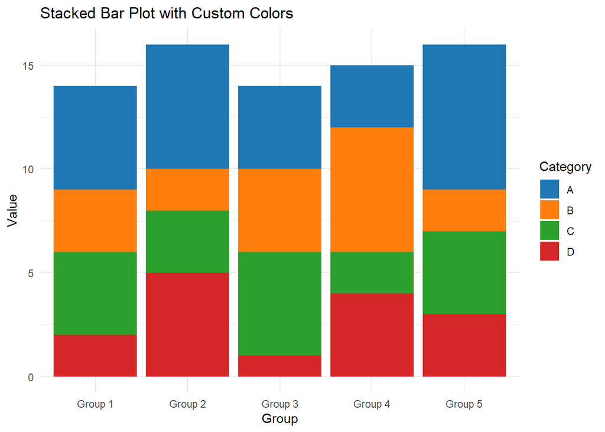

```r
# Load ggplot2
library(ggplot2)

# Create a simple dataset
data <- data.frame(
  Group = rep(paste("Group", 1:5), each = 4),
  Category = rep(c("A", "B", "C", "D"), times = 5),
  Value = c(5, 3, 4, 2,
            6, 2, 3, 5,
            4, 4, 5, 1,
            3, 6, 2, 4,
            7, 2, 4, 3)
)

# Stacked bar plot with custom colors
ggplot(data, aes(x = Group, y = Value, fill = Category)) +
  geom_bar(stat = "identity") +
  scale_fill_manual(values = c("A" = "#1f77b4",  # blue
                               "B" = "#ff7f0e",  # orange
                               "C" = "#2ca02c",  # green
                               "D" = "#d62728")) +  # red
  labs(title = "Stacked Bar Plot with Custom Colors",
       x = "Group",
       y = "Value") +
  theme_minimal()
```

### Mit Package:

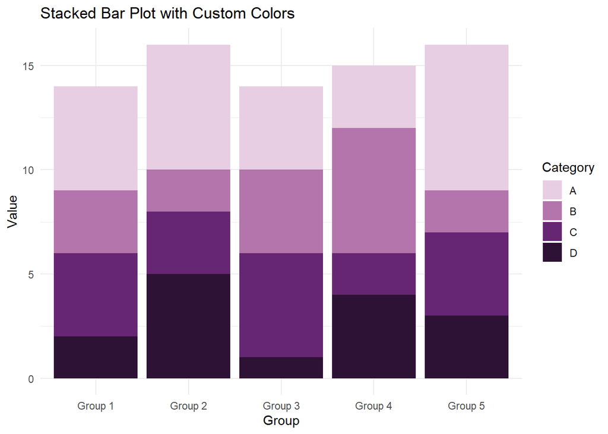

```r
# Load ggplot2
library(ggplot2)
# Remote via github:
remotes::install_github("guitarfly/TestPackage")
library(TestPackage)


# Create a simple dataset
data <- data.frame(
  Group = rep(paste("Group", 1:5), each = 4),
  Category = rep(c("A", "B", "C", "D"), times = 5),
  Value = c(5, 3, 4, 2,
            6, 2, 3, 5,
            4, 4, 5, 1,
            3, 6, 2, 4,
            7, 2, 4, 3)
)

# Stacked bar plot with custom colors
ggplot(data, aes(x = Group, y = Value, fill = Category)) +
  geom_bar(stat = "identity") +
  scale_fill_manual(values = TestPackage::violet4) +  # Dynamische Farben aus Package
  labs(title = "Stacked Bar Plot with Custom Colors",
       x = "Group",
       y = "Value") +
  theme_minimal()
```

Oder sogar:

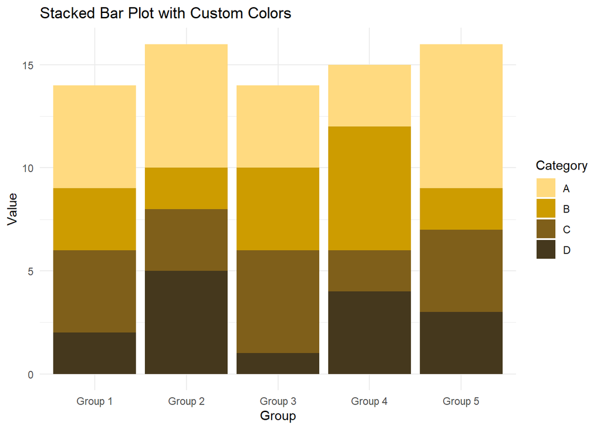

```r
# Load ggplot2
library(ggplot2)
# Remote via github:
remotes::install_github("guitarfly/TestPackage")
library(TestPackage)


# Create a simple dataset
data <- data.frame(
  Group = rep(paste("Group", 1:5), each = 4),
  Category = rep(c("A", "B", "C", "D"), times = 5),
  Value = c(5, 3, 4, 2,
            6, 2, 3, 5,
            4, 4, 5, 1,
            3, 6, 2, 4,
            7, 2, 4, 3)
)

# Stacked bar plot with custom plot and color function
stacked_bar(
  data = data,
  x_axis = "Group",
  y_axis = "Value",
  title = "Stacked Bar Plot with Custom Colors",
  legend_title = "Category",
  x_label = "Group",
  y_label = "Value",
  color = TestPackage::yellow4
)
```

## Vor- und Nachteile von R-Packages

### Vorteile

- **Wiederverwendbarer Code:** Einmal entwickelt, überall einsetzbar
- **Saubere Struktur:** Funktionen, Tests, Daten, Dokumentation klar getrennt
- **Einfache Weitergabe:** Auf GitHub oder CRAN teilbar
- **Qualitätssicherung:** Dokumentation und Tests verbessern Zuverlässigkeit
- **Versionierung:** Ermöglicht reproduzierbare Analysen und stabile Releases

### Nachteile

- **Höherer Initialaufwand:** Einrichtung, Dokumentation und Tests benötigen Zeit
- **Komplexität:** Für kleine Projekte eventuell überdimensioniert

## Fazit

Das Erstellen eigener R-Packages ist ein professioneller Weg, um R-Code strukturiert, dokumentiert und wiederverwendbar zu gestalten. Auch wenn der Einstieg etwas Aufwand erfordert, bietet diese Vorgehensweise langfristig klare Vorteile in Bezug auf Wartbarkeit, Qualität und Zusammenarbeit.

Selbst kleine Hilfsfunktionen lohnen sich oft als internes Package – für konsistente und saubere Projekte.